# BKC Research Sprint - Spring 2024

[figure not shown]

### Visualizing Boston's Urban Spaces Using Open Data

## Group 5: Landmarks of Boston

**Team Members: Justin Wei, Gemma Li, Kevin Hu and Krithika Balaraman**

### Exploratory Data Analysis and Visualization Drafts

### Our Concept

The registered landmarks of Boston are well documented with justifications of why they earned landmarks status, when they were petitioned for and who petitioned for them. The reports date back to the early 1900s and paint a colorful picture of the history of the city, and dedicated residents who worked to preserve it.

On the flipside, the city also documents applications that were rejected, or petitions that still await landmark status. Some of these structures have been demolished during the wait.

Our vision is to create multi-dimensional views of the city of Boston, based on the wildly differing experiences of these different petitioners and landmarks.

Additionally, we invite the audience to share their meaningful places, which would become their very own landmarks of Boston.

## Workflow 1 - Initial Data Processing

### Data Explorations

```python
# Load libraries
import pandas as pd
import textwrap
```

Dataset: BOSTON BUILDINGS INVENTORY

Source: https://data.boston.gov/dataset/boston-buildings-inventory

Description: This dataset pulls from many different data sources to identify individual building characteristics of all buildings in Boston. It also identifies high-potential retrofit options to reduce carbon emissions in multifamily buildings, using the best available data and assumptions from building experts.

```python
# Load main datafile: BOSTON BUILDING INVENTORY
df = pd.read_csv("building_inventory_021020.csv")
df.head()
```

|  | id | pid_long | cm_id | building_typology | building_subtypology | use_class | sqft_class | year_built_class | st_num | st_name | ... | insulate_exposed_ducts | insulate_exposed_pipes | interior_wall_insulation_blow_in | exterior_wall_insulation_at_replacement | exterior_wall_insulation | interior_wall_insulation_board | insulate_spandrel | asbestos | seal_elevator_vent_shafts | env_recommendation_count |
| --- | --- | --- | --- | --- | --- | --- | --- | --- | --- | --- | --- | --- | --- | --- | --- | --- | --- | --- | --- | --- | --- |
| 0 | 88905 | NaN | NaN | NaN | NaN | NaN | NaN | NaN | NaN | NaN | ... | f | f | f | f | f | f | f | f | f | 0 |
| 1 | 51137 | 1600083000 | NaN | Single-Family | Single-Family, 1915-1949 | Residential | < 25,000 sqft | 1915-1949 | 5 | EVERETT | ... | f | t | f | f | t | t | f | f | f | 4 |
| 2 | 18045 | 202560000 | NaN | Single-Family | Single-Family, Pre-1915 | Residential | < 25,000 sqft | Pre-1915 | 43 | ESSEX | ... | f | t | f | f | f | t | f | f | f | 3 |
| 3 | 94001 | 2200577000 | NaN | Convention/Assembly | Convention/Assembly, 1950-1979 | Public & Quasi-Public | < 25,000 sqft | 1950-1979 | 525 | WESTERN | ... | f | f | f | f | f | f | f | f | f | 0 |
| 4 | 92940 | 1600058000 | NaN | NaN | NaN | NaN | NaN | NaN | NaN | NaN | ... | f | f | f | f | f | f | f | f | f | 0 |

5 rows × 107 columns

```python
print("This dataset contains", df.shape[0], "entries building information, with", df.shape[1], "attributes for each.")
```

```
This dataset contains 98930 entries building information, with 107 attributes for each.
```

```python
columns_str = ', '.join(df.columns.tolist())
wrapped_columns = textwrap.fill(columns_str, width=128)
print("Here is a full list of all the columns / attributes:\n\n"+wrapped_columns)
```

```
Here is a full list of all the columns / attributes:

id, pid_long, cm_id, building_typology, building_subtypology, use_class, sqft_class, year_built_class, st_num, st_name,
st_name_suf, unit_num, zipcode, yr_built, land_sf, gross_area, living_area, sqft, num_floors, num_bldgs, units_res, units_com,
units_mixed, ptype, ptype_list, lu, lu_list, assessor_category, assessor_description, own_occ, own_occ_list, owner_list,
structure_class, structure_class_list, bldg_styl, bldg_styl_list, r_roof_typ, ext_fin, ext_fin_list, ext_cond_list,
insulation_type, foundation_type, heat_typ, heat_typ_list, heating_system_fuel, ac, ac_list, ac_system_type,
hot_water_system_fuel, electric_panel_info, has_pv, existing_ashp, existing_gshp, existing_shw, historic_district, landmark,
flood, stormwater, last_major_renovation_date, total_site_energy_kbtu, perc_electricity, perc_gas, perc_steam,
onsite_renewable_kwh, census_tract_number, ct_pop_disability, ct_pop_children_under_5, ct_pop_over_65, ct_pop_low_to_no_income,
ct_pop_limited_english_proficiency, ct_pop_poc, ct_pop_med_illness, ct_perc_disability, ct_perc_children_under_5,
ct_perc_over_65, ct_perc_low_to_no_income, ct_perc_limited_english_proficiency, ct_perc_poc, ct_perc_med_illness,
ct_hh_income_200000_or_more, ct_perc_income_200000_or_more, cashp_only, cashp_and_elec_upgrade, cashp_outdoor, dashp_only,
dashp_and_elec_upgrade, dashp_outdoor, gshp_only, gshp_and_elec_upgrade, vrf_only, vrf_and_elec_upgrade, awhp_only,
awhp_and_elec_upgrade, hp_recommendation_count, insulate_attic, insulate_attic_converted, ext_roof_insulation,
insulate_exposed_ducts, insulate_exposed_pipes, interior_wall_insulation_blow_in, exterior_wall_insulation_at_replacement,
exterior_wall_insulation, interior_wall_insulation_board, insulate_spandrel, asbestos, seal_elevator_vent_shafts,
env_recommendation_count
```

```python
df_description = pd.read_csv("fields-definitions.csv")
df_description['Field Name'] = df_description['Field Name'].str.strip() # Cleansing for extra spaces
df_cat = df_description.Category.unique()
print("Main", len(df_cat), "attribute categories:\n\n", df_cat)
```

```
Main 13 attribute categories:

 ['General information' 'Uses' 'Other' 'Building age' 'Building size'
 'Height' 'Number of buildings' 'Number of units' 'Zoning' 'Socioeconomic'
 'Environmental' 'Heat Pump Strategy' 'Envelope Strategy']
```

With the supplementary data fields descriptions file, we see that there are 13 main categories of attributes. We can use this to group the 107 attributes into smaller groups for easier operations.

The dataset contains all buildings in Boston, but we are only interested in those that are landmarks:

```python
filtered_df = df[df['landmark'] == 't']
print("Number of all landmarks:", len(filtered_df))
```

```
Number of all landmarks: 632
```

Check if there is anything be of our interests in the `Uses` attributes:

```python
df_description[df_description.Category == "Uses"][["Field Name", "Description"]]
```

|  | Field Name | Description |
| --- | --- | --- |
| 8 | ptype | Property type code |
| 9 | ptype_list | List of property type codes (where data was ag... |
| 10 | lu | Land use code |
| 11 | lu_list | List of land use codes (where data was aggrega... |
| 12 | own_occ | Whether the property receives a tax exemption ... |
| 13 | own_occ_list | List of owner occupany types (where data was a... |
| 37 | assessor_category | Property type category associated with ptype |
| 38 | assessor_description | Property type description associated with ptype |
| 76 | use_class | General use classification |
| 79 | building_typology | General building typology classification |
| 80 | building_subtypology | Building typology classification including sub... |

```python
filtered_df[df_description[df_description.Category == "Uses"]["Field Name"].tolist()].head()
```

|  | ptype | ptype_list | lu | lu_list | own_occ | own_occ_list | assessor_category | assessor_description | use_class | building_typology | building_subtypology |
| --- | --- | --- | --- | --- | --- | --- | --- | --- | --- | --- | --- |
| 3 | 941.0 | 941 | E | E | N | N | Exempt Property Type | Auditorium / Theater | Public & Quasi-Public | Convention/Assembly | Convention/Assembly, 1950-1979 |
| 71 | 986.0 | 986 | E | E | N | N | Exempt Property Type | Vacant Land | Vacant | Vacant | Vacant |
| 112 | 102.0 | 102,995 | CD | CD,CM | N | N,Y | Residential Property | Residential Condo | Residential | Multi-Family (>= 100 units) | Multi-Family (>= 100 units), 1980-present |
| 124 | 995.0 | 995 | CM | CM | N | N | Exempt Property Type | Condo Main | Residential (Mixed-Use) | Residential (Mixed-Use) | Residential (Mixed-Use), 1980-present |
| 129 | 995.0 | 995 | CM | CM | N | N | Exempt Property Type | Condo Main | Residential | Single-Family | Single-Family, 1980-present |

We want to look at what are the `General Use Classification` of these landmarks:

```python
filtered_df.groupby('use_class').size().sort_values(ascending=False)
```

```
use_class
Residential                209
Public & Quasi-Public      198
Commercial                 155
Vacant                      35
Residential (Mixed-Use)     34
Industrial                   1
dtype: int64
```

**⭐ Findings:**

- 33% of the landmarks are `Residential`, 31% are `Public & Quasi-Public`, 25% are `Commercial`.

Fixing defective entry of `Field Name` in the fields descriptions dataset:

> `KeyError: "['perc_gas numeric'] not in index"`

```python
df_description.loc[df_description['Field Name'] == 'perc_gas numeric', 'Field Name'] = 'perc_gas'
```

**Data Cleansing**

Checking for missing data by attribute categories:

> 'General information' 'Uses' 'Other' 'Building age' 'Building size' 'Height' 'Number of buildings' 'Number of units' 'Zoning' 'Socioeconomic' 'Environmental' 'Heat Pump Strategy' 'Envelope Strategy'

```python
# for cat in df_cat:
#    filtered_df[df_description[df_description.Category == cat]["Field Name"].tolist()].info(verbose=True, show_counts=True)
```

```python
df_description[df_description.Category == "General information"][["Field Name", "Description"]]
```

|  | Field Name | Description |
| --- | --- | --- |
| 0 | id | Unique ID |
| 1 | pid_long | Parcel ID |
| 2 | cm_id | Condo Main ID |
| 3 | st_num | Street number |
| 4 | st_name | Street name |
| 5 | st_name_suf | Street name suffix |
| 6 | unit_num | Address unit number |
| 7 | zipcode | Zip code |
| 14 | owner_list | List of property owners |

```python
filtered_df[df_description[df_description.Category == 'General information']["Field Name"].tolist()].isnull().sum()
```

```
id               0
pid_long         0
cm_id          544
st_num          88
st_name         88
st_name_suf     88
unit_num       632
zipcode         88
owner_list       0
dtype: int64
```

```python
df_description[df_description.Category == "Uses"][["Field Name", "Description"]]
```

|  | Field Name | Description |
| --- | --- | --- |
| 8 | ptype | Property type code |
| 9 | ptype_list | List of property type codes (where data was ag... |
| 10 | lu | Land use code |
| 11 | lu_list | List of land use codes (where data was aggrega... |
| 12 | own_occ | Whether the property receives a tax exemption ... |
| 13 | own_occ_list | List of owner occupany types (where data was a... |
| 37 | assessor_category | Property type category associated with ptype |
| 38 | assessor_description | Property type description associated with ptype |
| 76 | use_class | General use classification |
| 79 | building_typology | General building typology classification |
| 80 | building_subtypology | Building typology classification including sub... |

```python
filtered_df[df_description[df_description.Category == 'Uses']["Field Name"].tolist()].isnull().sum()
```

```
ptype                     0
ptype_list                0
lu                        0
lu_list                   0
own_occ                   0
own_occ_list              0
assessor_category         0
assessor_description      0
use_class                 0
building_typology       110
building_subtypology    175
dtype: int64
```

```python
df_description[df_description.Category == "Other"][["Field Name", "Description"]]
```

|  | Field Name | Description |
| --- | --- | --- |
| 15 | land_sf | Land area of parcel (square feet) |
| 21 | structure_class | Commercial building structure class (e.g. meta... |
| 22 | structure_class_list | List of building stucture classes (where data ... |
| 23 | bldg_styl | Building style (decker, row middle, row end, e... |
| 24 | bldg_styl_list | List of building styles (where data was aggreg... |
| 25 | r_roof_typ | Roof type for residential parcels (e.g. flat, ... |
| 26 | ext_fin | Exterior finish (e.g. brick/stone, stucco) |
| 27 | ext_fin_list | List of exterior finishes (where data was aggr... |
| 28 | heat_typ | Heating system type |
| 29 | heat_typ_list | List of heating system types (where data was a... |
| 30 | ac | Air conditioning system type |
| 31 | ac_list | List of air conditioning system types (where d... |
| 32 | ext_cond_list | List of exterior conditions |
| 41 | has_pv | Whether the property has solar panels |
| 42 | last_major_renovation_date | The last major renovation date of the property |
| 43 | heating_system_fuel | Heating system and heating fuel information |
| 44 | ac_system_type | AC system information |
| 45 | hot_water_system_fuel | Hot water system and hot water fuel information |
| 46 | insulation_type | Description of insulation |
| 47 | foundation_type | Description of foundation |
| 48 | electric_panel_info | Electric panel information |
| 49 | existing_ashp | Whether this property already has an air-sourc... |
| 50 | existing_gshp | Whether this property already has a ground-sou... |
| 51 | existing_shw | Whether this property already has a solar hot ... |
| 52 | total_site_energy_kbtu | Total annual energy use in kBTU |
| 53 | perc_electricity | Percentage of total annual energy use from ele... |
| 54 | perc_gas | Percentage of total annual energy use from gas |
| 55 | perc_steam | Percentage of total annual energy use from steam |
| 56 | onsite_renewable_kwh | Total annual on-site renewable energy producti... |

```python
filtered_df[df_description[df_description.Category == 'Other']["Field Name"].tolist()].isnull().sum()
```

```
land_sf                         0
structure_class               181
structure_class_list          181
bldg_styl                     466
bldg_styl_list                466
r_roof_typ                    469
ext_fin                       466
ext_fin_list                  466
heat_typ                      473
heat_typ_list                 476
ac                            476
ac_list                       476
ext_cond_list                 466
has_pv                        622
last_major_renovation_date    352
heating_system_fuel           632
ac_system_type                632
hot_water_system_fuel         631
insulation_type               632
foundation_type               631
electric_panel_info           631
existing_ashp                 632
existing_gshp                 632
existing_shw                  632
total_site_energy_kbtu        562
perc_electricity              562
perc_gas                      576
perc_steam                    617
onsite_renewable_kwh          632
dtype: int64
```

```python
df_description[df_description.Category == "Building age"][["Field Name", "Description"]]
```

|  | Field Name | Description |
| --- | --- | --- |
| 16 | yr_built | Year built |
| 78 | year_built_class | Building age classification |

```python
filtered_df[df_description[df_description.Category == 'Building age']["Field Name"].tolist()].isnull().sum()
```

```
yr_built            140
year_built_class    140
dtype: int64
```

```python
df_description[df_description.Category == "Building size"][["Field Name", "Description"]]
```

|  | Field Name | Description |
| --- | --- | --- |
| 17 | gross_area | Building area for commercial parcels (square f... |
| 18 | living_area | Building living area for residential parcels (... |
| 19 | sqft | Building area (square feet) |
| 77 | sqft_class | Square footage classification based on sqft field |

```python
filtered_df[df_description[df_description.Category == 'Building size']["Field Name"].tolist()].isnull().sum()
```

```
gross_area      19
living_area     19
sqft           105
sqft_class     136
dtype: int64
```

```python
df_description[df_description.Category == "Height"][["Field Name", "Description"]]
```

|  | Field Name | Description |
| --- | --- | --- |
| 20 | num_floors | Number of floors |

```python
filtered_df[df_description[df_description.Category == 'Height']["Field Name"].tolist()].isnull().sum()
```

```
num_floors    125
dtype: int64
```

```python
df_description[df_description.Category == "Number of buildings"][["Field Name", "Description"]]
```

|  | Field Name | Description |
| --- | --- | --- |
| 33 | num_bldgs | Number of buildings |

```python
filtered_df[df_description[df_description.Category == 'Number of buildings']["Field Name"].tolist()].isnull().sum()
```

```
num_bldgs    41
dtype: int64
```

```python
df_description[df_description.Category == "Number of units"][["Field Name", "Description"]]
```

|  | Field Name | Description |
| --- | --- | --- |
| 34 | units_res | Number of residential units |
| 35 | units_com | Number of commercial units |
| 36 | units_mixed | Number of mixed-use units |

```python
filtered_df[df_description[df_description.Category == 'Number of units']["Field Name"].tolist()].isnull().sum()
```

```
units_res      418
units_com      540
units_mixed    544
dtype: int64
```

```python
df_description[df_description.Category == "Zoning"][["Field Name", "Description"]]
```

|  | Field Name | Description |
| --- | --- | --- |
| 39 | historic_district | Whether the property is in a historic district |
| 40 | landmark | Whether the property is in a landmark district |

```python
filtered_df[df_description[df_description.Category == 'Zoning']["Field Name"].tolist()].isnull().sum()
```

```
historic_district    0
landmark             0
dtype: int64
```

```python
df_description[df_description.Category == "Socioeconomic"][["Field Name", "Description"]]
```

|  | Field Name | Description |
| --- | --- | --- |
| 57 | census_tract_number | Census Tract number |
| 58 | ct_pop_disability | Population in Census Tract of people with disa... |
| 59 | ct_pop_children_under_5 | Population in Census Tract under 5 years old |
| 60 | ct_pop_over_65 | Population in Census Tract over 65 years old |
| 61 | ct_pop_low_to_no_income | Population in Census Tract with income 100% be... |
| 62 | ct_pop_limited_english_proficiency | Population in Census Tract with limited Englis... |
| 63 | ct_pop_poc | Population in Census Tract of people of color |
| 64 | ct_pop_med_illness | Population in Census Tract of people with medi... |
| 65 | ct_perc_disability | Percentage of population in Census Tract of pe... |
| 66 | ct_perc_children_under_5 | Percentage of population in Census Tract under... |
| 67 | ct_perc_over_65 | Percentage of population in Census Tract over ... |
| 68 | ct_perc_low_to_no_income | Percentage of population in Census Tract with ... |
| 69 | ct_perc_limited_english_proficiency | Percentage of population in Census Tract with ... |
| 70 | ct_perc_poc | Percentage of population in Census Tract of pe... |
| 71 | ct_perc_med_illness | Percentage of population in Census Tract of pe... |
| 72 | ct_hh_income_200000_or_more | Number of households in Census Tract with inco... |
| 73 | ct_perc_income_200000_or_more | Percentage of households in Census Tract with ... |

```python
filtered_df[df_description[df_description.Category == 'Socioeconomic']["Field Name"].tolist()].isnull().sum()
```

```
census_tract_number                    12
ct_pop_disability                      12
ct_pop_children_under_5                12
ct_pop_over_65                         12
ct_pop_low_to_no_income                12
ct_pop_limited_english_proficiency     12
ct_pop_poc                             12
ct_pop_med_illness                     12
ct_perc_disability                     12
ct_perc_children_under_5               12
ct_perc_over_65                        12
ct_perc_low_to_no_income               12
ct_perc_limited_english_proficiency    12
ct_perc_poc                            12
ct_perc_med_illness                    12
ct_hh_income_200000_or_more            20
ct_perc_income_200000_or_more          20
dtype: int64
```

```python
df_description[df_description.Category == "Environmental"][["Field Name", "Description"]]
```

|  | Field Name | Description |
| --- | --- | --- |
| 74 | flood | Whether the property falls within the 1% annua... |
| 75 | stormwater | Whether the property falls within the stormwat... |

```python
filtered_df[df_description[df_description.Category == 'Environmental']["Field Name"].tolist()].isnull().sum()
```

```
flood         0
stormwater    0
dtype: int64
```

```python
df_description[df_description.Category == "Heat Pump Strategy"][["Field Name", "Description"]]
```

|  | Field Name | Description |
| --- | --- | --- |
| 81 | cashp_only | Whether ducted (central) air source heat pump ... |
| 82 | cashp_and_elec_upgrade | Whether ducted (central) air source heat pump ... |
| 83 | cashp_outdoor | Whether ducted (central) air source heat pump ... |
| 84 | dashp_only | Whether ductless air source heat pump replacem... |
| 85 | dashp_and_elec_upgrade | Whether ductless air source heat pump replacem... |
| 86 | dashp_outdoor | Whether ductless air source heat pump replacem... |
| 87 | gshp_only | Whether ground source heat pump replacement or... |
| 88 | gshp_and_elec_upgrade | Whether ground source heat pump replacement or... |
| 89 | vrf_only | Whether variable refrigerant flow replacement ... |
| 90 | vrf_and_elec_upgrade | Whether variable refrigerant flow replacement ... |
| 91 | awhp_only | Whether air-to-water heat pump replacement or ... |
| 92 | awhp_and_elec_upgrade | Whether air-to-water heat pump replacement or ... |
| 93 | hp_recommendation_count | The number of heat pump retrofit strategies re... |

```python
filtered_df[df_description[df_description.Category == 'Heat Pump Strategy']["Field Name"].tolist()].isnull().sum()
```

```
cashp_only                 0
cashp_and_elec_upgrade     0
cashp_outdoor              0
dashp_only                 0
dashp_and_elec_upgrade     0
dashp_outdoor              0
gshp_only                  0
gshp_and_elec_upgrade      0
vrf_only                   0
vrf_and_elec_upgrade       0
awhp_only                  0
awhp_and_elec_upgrade      0
hp_recommendation_count    0
dtype: int64
```

```python
df_description[df_description.Category == "Envelope Strategy"][["Field Name", "Description"]]
```

|  | Field Name | Description |
| --- | --- | --- |
| 94 | insulate_attic | Whether attic insulation is recommended |
| 95 | insulate_attic_converted | Whether insulation is recommended in a convert... |
| 96 | ext_roof_insulation | Whether exterior roof insulation is recommended |
| 97 | insulate_exposed_ducts | Whether insulating exposed ducts is recommended |
| 98 | insulate_exposed_pipes | Whether insulating exposed pipes is recommended |
| 99 | interior_wall_insulation_blow_in | Whether blow-in interior wall insulation is re... |
| 100 | exterior_wall_insulation_at_replacement | Whether exterior wall insulation is recommende... |
| 101 | exterior_wall_insulation | Whether exterior wall insulation is recommended |
| 102 | interior_wall_insulation_board | Whether board interior wall insulation is reco... |
| 103 | insulate_spandrel | Whether insulating spandrels is recommanded |
| 104 | asbestos | Whether the property's exterior finish is comp... |
| 105 | seal_elevator_vent_shafts | Whether sealing elevator vent shafts is recomm... |
| 106 | env_recommendation_count | The number of envelope retrofit strategies rec... |

```python
filtered_df[df_description[df_description.Category == 'Envelope Strategy']["Field Name"].tolist()].isnull().sum()
```

```
insulate_attic                             0
insulate_attic_converted                   0
ext_roof_insulation                        0
insulate_exposed_ducts                     0
insulate_exposed_pipes                     0
interior_wall_insulation_blow_in           0
exterior_wall_insulation_at_replacement    0
exterior_wall_insulation                   0
interior_wall_insulation_board             0
insulate_spandrel                          0
asbestos                                   0
seal_elevator_vent_shafts                  0
env_recommendation_count                   0
dtype: int64
```

**⭐ Findings:**

- In `General Information` category, we will rely on `st_num`, `st_name`, and `zipcode` in order to locate the respective building on a map. There are 88 entries that are missing the street address information, so we will drop those entries.
- In `Uses` category, there are over 100 entries has missing values in `building_typology` and `building_subtypology`, which are the "General building typology classification" and "Building typology classification including subtypology based on building age". We have not decided what to do with this pair of features, so we are keeping these entries for now.
- In `Other` category, only `land_sf` has no missing data; all other attributes have great missingness and are mostly unuseable. We may consider only keeping the "Land area of parcel (square feet)" and dropping all other columns.
- in `Building age` category, `yr_built` is a key attribute we will be using for our visualization. There are 140 entries are missing "Year built" so we will have to drop those entries.
- in `Building size`, `Height`, `Number of buildings`, `Number of units` categories, there are a few entries missing `sqft`, `sqft_class`, `num_floors`, `num_bldgs`, `units_res`, `units_com`, `units_mixed`. We will keep these for now as we continue exploring.
- in `Socioeconomic` category, all attributes are related to Census Tract, we will set them aside for now as we continue exploring.

Now dropping select entries with missing data:

```python
cols_to_scan = ['st_num', 'st_name', 'zipcode', 'yr_built']
cols_to_drop = ['bldg_styl',
 'bldg_styl_list',
 'r_roof_typ',
 'ext_fin',
 'ext_fin_list',
 'heat_typ',
 'heat_typ_list',
 'ac',
 'ac_list',
 'ext_cond_list',
 'has_pv',
 'last_major_renovation_date',
 'heating_system_fuel',
 'ac_system_type',
 'hot_water_system_fuel',
 'insulation_type',
 'foundation_type',
 'electric_panel_info',
 'existing_ashp',
 'existing_gshp',
 'existing_shw',
 'total_site_energy_kbtu',
 'perc_electricity',
 'perc_gas',
 'perc_steam',
 'onsite_renewable_kwh']
```

```python
filtered_df = filtered_df.drop(columns=cols_to_drop)
```

```python
cleaned_filtered_df = filtered_df.dropna(subset=cols_to_scan, how='any')
cleaned_filtered_df = cleaned_filtered_df.drop(columns=df_description[df_description.Category == 'Socioeconomic']["Field Name"].tolist())
```

Dataset overview after cleansing:

```python
cleaned_filtered_df.describe()
```

|  | id | cm_id | unit_num | zipcode | yr_built | land_sf | gross_area | living_area | sqft | num_floors | num_bldgs | units_res | units_com | units_mixed | ptype | hp_recommendation_count | env_recommendation_count |
| --- | --- | --- | --- | --- | --- | --- | --- | --- | --- | --- | --- | --- | --- | --- | --- | --- | --- |
| count | 404.000000 | 0.0 | 0.0 | 404.000000 | 404.000000 | 4.040000e+02 | 4.040000e+02 | 4.040000e+02 | 4.040000e+02 | 402.000000 | 404.0 | 125.000000 | 4.000000 | 0.0 | 404.000000 | 404.000000 | 404.00000 |
| mean | 53269.274752 | NaN | NaN | 2132.534653 | 1917.596535 | 8.639063e+04 | 7.636403e+04 | 6.616423e+04 | 7.486486e+04 | 4.889303 | 1.0 | 19.584000 | 5.000000 | NaN | 431.000000 | 0.131188 | 0.75495 |
| std | 29931.118523 | NaN | NaN | 37.440325 | 31.783356 | 5.091808e+05 | 1.832390e+05 | 1.643976e+05 | 1.830248e+05 | 5.209411 | 0.0 | 38.648787 | 1.154701 | NaN | 374.490642 | 0.410915 | 1.14543 |
| min | 7.000000 | NaN | NaN | 2108.000000 | 1845.000000 | 0.000000e+00 | 1.000000e+00 | 1.000000e+00 | 1.000000e+00 | 1.000000 | 1.0 | 1.000000 | 4.000000 | NaN | 13.000000 | 0.000000 | 0.00000 |
| 25% | 25174.250000 | NaN | NaN | 2111.000000 | 1899.000000 | 4.006000e+03 | 6.145750e+03 | 4.321500e+03 | 5.043000e+03 | 2.000000 | 1.0 | 2.000000 | 4.000000 | NaN | 105.000000 | 0.000000 | 0.00000 |
| 50% | 60248.500000 | NaN | NaN | 2119.000000 | 1906.000000 | 9.548500e+03 | 1.721000e+04 | 1.364500e+04 | 1.549000e+04 | 4.000000 | 1.0 | 3.000000 | 5.000000 | NaN | 327.000000 | 0.000000 | 0.00000 |
| 75% | 78442.750000 | NaN | NaN | 2130.000000 | 1925.000000 | 2.535450e+04 | 6.604075e+04 | 5.308875e+04 | 6.520075e+04 | 5.000000 | 1.0 | 24.000000 | 6.000000 | NaN | 906.000000 | 0.000000 | 1.00000 |
| max | 98792.000000 | NaN | NaN | 2467.000000 | 2018.000000 | 7.397130e+06 | 1.502842e+06 | 1.409965e+06 | 1.502842e+06 | 42.000000 | 1.0 | 273.000000 | 6.000000 | NaN | 986.000000 | 3.000000 | 3.00000 |

```python
cleaned_filtered_df.head()
```

|  | id | pid_long | cm_id | building_typology | building_subtypology | use_class | sqft_class | year_built_class | st_num | st_name | ... | insulate_exposed_ducts | insulate_exposed_pipes | interior_wall_insulation_blow_in | exterior_wall_insulation_at_replacement | exterior_wall_insulation | interior_wall_insulation_board | insulate_spandrel | asbestos | seal_elevator_vent_shafts | env_recommendation_count |
| --- | --- | --- | --- | --- | --- | --- | --- | --- | --- | --- | --- | --- | --- | --- | --- | --- | --- | --- | --- | --- | --- |
| 3 | 94001 | 2200577000 | NaN | Convention/Assembly | Convention/Assembly, 1950-1979 | Public & Quasi-Public | < 25,000 sqft | 1950-1979 | 525 | WESTERN | ... | f | f | f | f | f | f | f | f | f | 0 |
| 170 | 4303 | 1002149000 | NaN | Multi-Family (>= 100 units) | Multi-Family (>= 100 units), 1950-1979 | Residential | >= 100,000 sqft | 1950-1979 | 111 | PERKINS | ... | f | f | f | f | f | f | f | f | t | 2 |
| 182 | 71547 | 303823000 | NaN | Multi-Family (31-99 units) | Multi-Family (31-99 units), Pre-1915 | Residential | >= 100,000 sqft | Pre-1915 | 131 | STATE | ... | f | f | f | f | f | f | f | f | t | 2 |
| 189 | 38651 | 304910020 | NaN | NaN | NaN | Residential | >= 100,000 sqft | 1980-present | 24 -58 | LAGRANGE | ... | f | f | f | f | f | f | f | f | t | 1 |
| 205 | 97181 | 303883000 | NaN | Hotel | Hotel, 1980-present | Commercial | 50,000-99,999 sqft | 1980-present | 56 - 68 | DEVONSHIRE | ... | f | f | f | f | f | f | f | f | t | 1 |

5 rows × 64 columns

**⭐ Findings:**

- For `yr_built`, the oldest landmark was built in 1845 (almost 200 years ago!); the newest landmark was built in 2018.
- For `land_sf`, the largest landmark sits on a land of 7397130 sqft, that's 170 acres! The largest `sqft`, the actual square footage is 1502842 sqft, that's 34.5 acres.
- The tallest landmarks has 42 floors according to `num_floors`.

**Getting Building Geographic Coordinate**

In order to be able to plot these landmarks buildings accurately on map, we need to use their corrosponding longitude and latitude coordinates. The dataset doesn't come with buildings' coordinates, so we will have to get the coordinates based on their street addresses.

**⭐ Next Steps:**

- We will need find a way to get geographic coordinated for all landmarks. There should be related dataset or API we can utilize from the City of Boston. Worst case scenario, we will use street address to inference respective coordinates.

### Additional Dataset

**Boston Landmarks Commission: List of All Submitted Petitions & Status**

The Boston Landmarks Commission (BLC) maintains a live list of all the petitions of with their status, whether they are pending, approved, or denied. This dataset would give us a better understanding about Boston's landmarks - we want to look at those that are still pending, and those were denied.

```python
blc_df = pd.read_excel("List of All Petitions & Status_ Live.xlsx")
```

```python
blc_df.head()
```

|  | PETITION | NAME OF PROPERTY | ADDRESS | NEIGHBORHOOD | PETITION BY | CATEGORY | DETAILS |
| --- | --- | --- | --- | --- | --- | --- | --- |
| 0 | 289 | Charlestown Industrial Architectural Conservat... | See Map | Charlestown | 10 voters | C = Pending Landmark/District | Under study - July 2023 |
| 1 | 288 | Hotel Buckminster | 635-645 Beacon Street | Kenmore | 10 voters | A = Individual Landmark | BLC designation vote 2023 |
| 2 | 287 | Monument Square Landmark District | See Map | Charlestown | 10 Voters | C = Pending Landmark/District | Under study - Jul 2022 |
| 3 | 286 | William S. Keith House | 1911 Centre St | West Roxbury | 10 voters | D = Designated or Pending but Demolished | Razed 2022 |
| 4 | 285 | Blue Hill Bank | 1110 Washington St | Mattapan | 10 voters | C = Pending Landmark/District | Under study - Mar 2022 |

### Convert Address to Latitude Longitude

Operations for Boston Building Dataset:

- Convert entries in `zipcode` field from 4 digits to 5 digits, simply adding 0 at the front
- Convert all `AV` in `st_name_suf` to `AVE` for address-to-coordiantes conversion accuracy
- Aggregate address related fields into one single full address field

```python
# Convert `zipcode`
cleaned_filtered_df['zipcode5'] = cleaned_filtered_df['zipcode'].apply(lambda x: '0' + str(int(x)) if x < 10000 else str(int(x)))
```

```python
# Replace AV with AVE
cleaned_filtered_df['st_name_suf'] = cleaned_filtered_df['st_name_suf'].replace('AV', "AVE")
```

```python
# Aggregate Address Fields
cleaned_filtered_df['full_address'] = cleaned_filtered_df['st_num'].astype(str) + ' ' + \
                                      cleaned_filtered_df['st_name'] + ' ' + \
                                      cleaned_filtered_df['st_name_suf'] + ', Boston, MA ' + \
                                      cleaned_filtered_df['zipcode5']
```

```python
cleaned_filtered_df['full_address'].head(10)
```

```
3             525 WESTERN AVE, Boston, MA 02135
170            111 PERKINS ST, Boston, MA 02130
182              131 STATE ST, Boston, MA 02109
189        24 -58 LAGRANGE ST, Boston, MA 02116
205     56 - 68 DEVONSHIRE ST, Boston, MA 02109
206      105 S HUNTINGTON AVE, Boston, MA 02199
208    659 -677 WASHINGTON ST, Boston, MA 02111
231      240 - 242 TREMONT ST, Boston, MA 02116
253         201 BROOKLINE AVE, Boston, MA 02215
260             100 SUMMER ST, Boston, MA 02110
Name: full_address, dtype: object
```

```python
# Install and Import Geopy Package
# !pip install geopy
from geopy.geocoders import Nominatim
import time
```

```python
geolocator = Nominatim(user_agent = "BostonLandmarkCoordinates")
```

```python
total_addresses = len(cleaned_filtered_df['full_address'])
processed_count = 0

for index, row in cleaned_filtered_df.iterrows():
    address = row['full_address']
    try:
        location = geolocator.geocode(address, timeout=10)
        if location:
            cleaned_filtered_df.at[index, 'lat'] = location.latitude
            cleaned_filtered_df.at[index, 'lon'] = location.longitude
            cleaned_filtered_df.at[index, 'coordinate'] = f"{location.latitude}, {location.longitude}"
        else:
            cleaned_filtered_df.at[index, 'lat'] = None
            cleaned_filtered_df.at[index, 'lon'] = None
            cleaned_filtered_df.at[index, 'coordinate'] = None
    except Exception as e:
            cleaned_filtered_df.at[index, 'lat'] = None
            cleaned_filtered_df.at[index, 'lon'] = None
            cleaned_filtered_df.at[index, 'coordinate'] = None
    finally:
        processed_count += 1
        print(f"\r{processed_count} out of {total_addresses} processed...{address} ==> {cleaned_filtered_df.at[index, 'coordinate']}", end="", flush=True)
        time.sleep(1)

print("\nDone.")
```

```
404 out of 404 processed...613 617 COLUMBIA RD, Boston, MA 02125 ==> 42.3177406, -71.063567905235030517395266
Done.
```

```python
# Check Results
print(cleaned_filtered_df[['full_address', 'lat', 'lon', 'coordinate']].head())
```

```
                                full_address        lat        lon  \
3          525 WESTERN AVE, Boston, MA 02135  42.361589 -71.144729
170         111 PERKINS ST, Boston, MA 02130  42.322224 -71.115426
182           131 STATE ST, Boston, MA 02109  42.358982 -71.054227
189     24 -58 LAGRANGE ST, Boston, MA 02116  42.351636 -71.064024
205  56 - 68 DEVONSHIRE ST, Boston, MA 02109  42.358282 -71.057281

                                 coordinate
3    42.361588714285716, -71.14472929591837
170                 42.3222244, -71.1154261
182         42.35898245, -71.05422705000001
189                 42.3516363, -71.0640237
205                 42.3582819, -71.0572806
```

```python
# Save the dataset for future use
cleaned_filtered_df.to_csv('building_data_with_coordinate.csv', index=False)
```

```python
# NEXT STEP:
# - Process `blc_df`
# - Retry those with NaN
# - Manually fill those with NaN (building data has 33)
```

Operations for Boston Landmarks Commission Dataset:

- Aggregate address related fields into one single full address field
- Attempt address-to-coordinate conversion without zipcode

```python
blc_df.head()
```

|  | PETITION | NAME OF PROPERTY | ADDRESS | NEIGHBORHOOD | PETITION BY | CATEGORY | DETAILS |
| --- | --- | --- | --- | --- | --- | --- | --- |
| 0 | 289 | Charlestown Industrial Architectural Conservat... | See Map | Charlestown | 10 voters | C = Pending Landmark/District | Under study - July 2023 |
| 1 | 288 | Hotel Buckminster | 635-645 Beacon Street | Kenmore | 10 voters | A = Individual Landmark | BLC designation vote 2023 |
| 2 | 287 | Monument Square Landmark District | See Map | Charlestown | 10 Voters | C = Pending Landmark/District | Under study - Jul 2022 |
| 3 | 286 | William S. Keith House | 1911 Centre St | West Roxbury | 10 voters | D = Designated or Pending but Demolished | Razed 2022 |
| 4 | 285 | Blue Hill Bank | 1110 Washington St | Mattapan | 10 voters | C = Pending Landmark/District | Under study - Mar 2022 |

```python
# Aggregate Address Fields
blc_df['full_address'] = blc_df['ADDRESS'] + ', ' + blc_df['NEIGHBORHOOD'] + ', MA, USA'
```

```python
blc_df['full_address'].head(10)
```

```
0              See Map, Charlestown, MA, USA
1    635-645 Beacon Street, Kenmore, MA, USA
2              See Map, Charlestown, MA, USA
3      1911 Centre St, West Roxbury, MA, USA
4      1110 Washington St, Mattapan, MA, USA
5          77 Bailey St, Dorchester, MA, USA
6    Babson-Cookson Tract, Mattapan, MA, USA
7    11-13 Humphreys St, Dorchester, MA, USA
8        37 Glendale St, Dorchester, MA, USA
9    10 Melville Avenue, Dorchester, MA, USA
Name: full_address, dtype: object
```

```python
total_addresses = len(blc_df['full_address'])
processed_count = 0

for index, row in blc_df.iterrows():
    address = row['full_address']
    try:
        location = geolocator.geocode(address, timeout=10)
        if location:
            blc_df.at[index, 'lat'] = location.latitude
            blc_df.at[index, 'lon'] = location.longitude
            blc_df.at[index, 'coordinate'] = f"{location.latitude}, {location.longitude}"
        else:
            blc_df.at[index, 'lat'] = None
            blc_df.at[index, 'lon'] = None
            blc_df.at[index, 'coordinate'] = None
    except Exception as e:
            blc_df.at[index, 'lat'] = None
            blc_df.at[index, 'lon'] = None
            blc_df.at[index, 'coordinate'] = None
    finally:
        processed_count += 1
        print(f"\r{processed_count} out of {total_addresses} processed...{address} ==> {blc_df.at[index, 'coordinate']}", end="", flush=True)
        time.sleep(1)

print("\nDone.")
```

```
304 out of 304 processed...nan ==> 46.3144754, 11.0480288 USA ==> 43.6239616, -116.1962685346312549264893935172069
Done.
```

```python
# Check Results
print(blc_df[['full_address', 'lat', 'lon', 'coordinate']].head())
```

```
                              full_address        lat        lon  \
0            See Map, Charlestown, MA, USA        NaN        NaN
1  635-645 Beacon Street, Kenmore, MA, USA  42.347132 -71.103330
2            See Map, Charlestown, MA, USA        NaN        NaN
3    1911 Centre St, West Roxbury, MA, USA  42.284986 -71.156858
4    1110 Washington St, Mattapan, MA, USA  42.272188 -71.068185

                        coordinate
0                              NaN
1          42.3471315, -71.1033303
2                             None
3  42.28498645, -71.15685764135037
4          42.2721879, -71.0681849
```

```python
# Save the dataset for future use
blc_df.to_csv('blc_data_with_coordinate.csv', index=False)
```

## Workflow 2 - Further Data Explorations

```python
# Load libraries
import pandas as pd
import textwrap

# Load saved datasets for reuse.
df_building = pd.read_csv("building_data_with_coordinate.csv")
df_blc = pd.read_csv("blc_data_with_coordinate.csv")
df_description = pd.read_csv("fields-definitions.csv")
df_description['Field Name'] = df_description['Field Name'].str.strip() # Cleansing for extra spaces
```

### Exploration on interesting features

#### `Uses` Category

- `ptype`, `ptype_list`, `assessor_category`, `assessor_description`, `use_class` are parallel information from *CODES AND CLASSES DEFINITIONS* supplementary dataset.

```python
# Category: Uses
df_building[df_building.columns.intersection(df_description[df_description.Category == "Uses"]["Field Name"].tolist())].head(20)
```

|  | building_typology | building_subtypology | use_class | ptype | ptype_list | lu | lu_list | assessor_category | assessor_description | own_occ | own_occ_list |
| --- | --- | --- | --- | --- | --- | --- | --- | --- | --- | --- | --- |
| 0 | Convention/Assembly | Convention/Assembly, 1950-1979 | Public & Quasi-Public | 941.0 | 941 | E | E | Exempt Property Type | Auditorium / Theater | N | N |
| 1 | Multi-Family (>= 100 units) | Multi-Family (>= 100 units), 1950-1979 | Residential | 13.0 | 13 | RC | RC | Multiple Use Property | Res/Commercial Use | N | N |
| 2 | Multi-Family (31-99 units) | Multi-Family (31-99 units), Pre-1915 | Residential | 13.0 | 13 | RC | RC | Multiple Use Property | Res/Commercial Use | N | N |
| 3 | NaN | NaN | Residential | 120.0 | 120 | A | A | Apartment Property | Apartment | N | N |
| 4 | Hotel | Hotel, 1980-present | Commercial | 300.0 | 300 | C | C | Commercial Property | Hotel/Lodging | N | N |
| 5 | Multi-Family (>= 100 units) | Multi-Family (>= 100 units), 1980-present | Residential | 13.0 | 13 | RC | RC | Multiple Use Property | Res/Commercial Use | N | N |
| 6 | Residential (Mixed-Use) | Residential (Mixed-Use), 1980-present | Residential (Mixed-Use) | 13.0 | 13 | RC | RC | Multiple Use Property | Res/Commercial Use | N | N |
| 7 | Hotel | Hotel, 1980-present | Commercial | 300.0 | 300 | C | C | Commercial Property | Hotel/Lodging | N | N |
| 8 | NaN | NaN | Public & Quasi-Public | 907.0 | 907 | EA | EA | Exempt Ownership | Exempt 121A Property | N | N |
| 9 | Office | Office, 1980-present | Commercial | 348.0 | 348 | C | C | Commercial Property | Office Building | N | N |
| 10 | Office | Office, 1950-1979 | Commercial | 347.0 | 347 | C | C | Commercial Property | Office Building | N | N |
| 11 | Office | Office, 1950-1979 | Commercial | 346.0 | 346 | C | C | Commercial Property | Office Building | N | N |
| 12 | NaN | NaN | Public & Quasi-Public | 985.0 | 985 | E | E | Exempt Property Type | Other Exempt Bldg | N | N |
| 13 | Worship | Worship, 1915-1949 | Public & Quasi-Public | 970.0 | 970 | E | E | Exempt Property Type | Church, Synagogue | N | N |
| 14 | Residential (Mixed-Use) | Residential (Mixed-Use), 1980-present | Residential (Mixed-Use) | 13.0 | 13 | RC | RC | Multiple Use Property | Res/Commercial Use | N | N |
| 15 | Hotel | Hotel, 1980-present | Commercial | 300.0 | 300 | C | C | Commercial Property | Hotel/Lodging | N | N |
| 16 | NaN | NaN | Public & Quasi-Public | 985.0 | 985 | E | E | Exempt Property Type | Other Exempt Bldg | N | N |
| 17 | Office | Office, 1915-1949 | Commercial | 346.0 | 346 | C | C | Commercial Property | Office Building | N | N |
| 18 | Office | Office, 1915-1949 | Commercial | 346.0 | 346 | C | C | Commercial Property | Office Building | N | N |
| 19 | Office | Office, Pre-1915 | Commercial | 347.0 | 347 | C | C | Commercial Property | Office Building | N | N |

```python
# Remove redundant and unuseful columns
df_building.drop('ptype_list', axis=1, inplace=True)
df_building.drop('lu_list', axis=1, inplace=True)
df_building.drop('own_occ_list', axis=1, inplace=True)

df_building.drop('own_occ', axis=1, inplace=True)
```

```python
df_building.groupby('building_typology').size().sort_values(ascending=False)
```

```
building_typology
Office                         73
Convention/Assembly            49
Single-Family                  29
Multi-Family (7-30 units)      25
Multi-Family (3 units)         23
Residential (Mixed-Use)        19
Multi-Family (31-99 units)     18
Multi-Family (2 units)         17
Retail                         16
Hotel                          10
Medical/Lab/Production         10
Multi-Family (4-6 units)       10
Restaurant                      9
Worship                         9
School                          6
Warehouse                       4
Multi-Family (>= 100 units)     4
Fire/Police                     2
Garage                          1
Supermarket                     1
Vacant                          1
dtype: int64
```

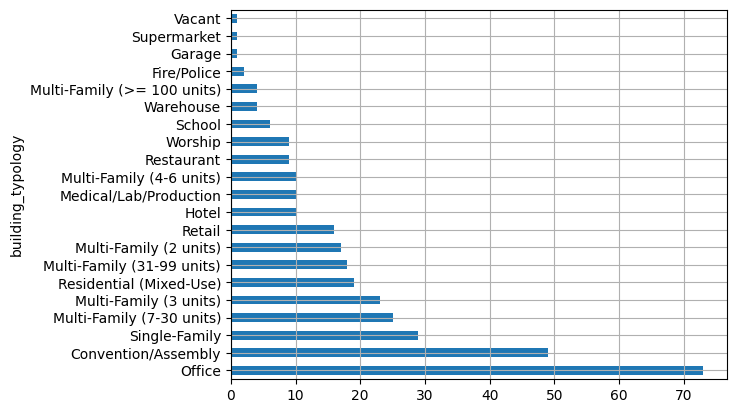

```python
df_building.groupby('building_typology').size().sort_values(ascending=False).plot(kind='barh', grid=True);
```

```python
df_building.groupby('use_class').size().sort_values(ascending=False)
```

```
use_class
Residential                136
Public & Quasi-Public      124
Commercial                 123
Residential (Mixed-Use)     19
Industrial                   1
Vacant                       1
dtype: int64
```

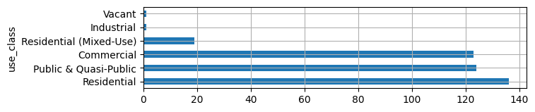

```python
df_building.groupby('use_class').size().sort_values(ascending=False).plot(kind='barh', grid=True, figsize=(7, 1.5));
```

```python
df_building.groupby('assessor_category').size().sort_values(ascending=False)
```

```
assessor_category
Commercial Property      110
Exempt Property Type      93
Residential Property      69
Apartment Property        55
Multiple Use Property     41
Exempt Ownership          35
Industrial Property        1
dtype: int64
```

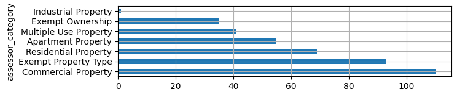

```python
df_building.groupby('assessor_category').size().sort_values(ascending=False).plot(kind='barh', grid=True, figsize=(7, 1.5));
```

```python
df_building.assessor_description.unique()
```

```
array(['Auditorium / Theater', 'Res/Commercial Use', 'Apartment',
       'Hotel/Lodging', 'Exempt 121A Property', 'Office Building',
       'Other Exempt Bldg', 'Church, Synagogue', 'College',
       'Three-Fam Dwelling', 'Single Fam Dwelling', 'Two-Fam Dwelling',
       'Charitable Organiztn', 'Multiple Buildings', 'Apt 31-99 Units',
       'Boston Housing Auth', 'Apt 7-30 Units', 'Service Plaza Retail',
       'Apt 4-6 Units', 'Com Multi-Use', 'Commonwealth of Mass',
       'Apt 100+ Units', 'Supermarket', 'Library', 'Religious Organizatn',
       'Hospital', 'Bost Redevelop Auth', 'Retail/Whlsale/Service',
       'Boat House / Marina', 'Fire Station', 'Laboratory', 'School',
       'Administrative Bldg', 'Vacant Land', 'Gas Station',
       'Parking Garage', 'Restaurant/Lounge', 'Office/Administr Bldg',
       'Office 1-2 Story', 'Rooming House', 'Assisted Living/Elderly',
       'Funeral Home', 'Dormitory', 'Warehouse', 'Retail Store',
       'Old Manufacturing', 'Auditorium / Sport Ctr', 'Bank Building',
       'Elderly Home', 'Priv School /College', 'Office 3-9 Story',
       'Residence Hall', 'Apt Subsidized Housing', 'Restaurant/Service',
       'Rectory, Convent', 'Retail/Office', 'Res/Comm Mixed Use',
       'Night Club', 'Medical Office', 'Stage Theater', 'City of Boston'],
      dtype=object)
```

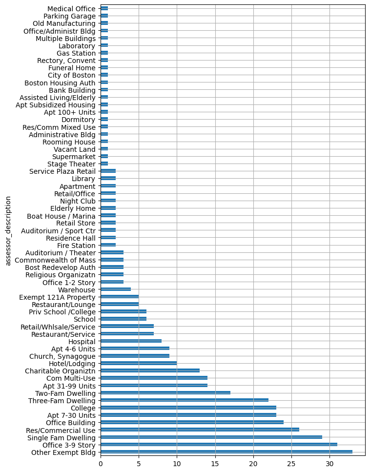

```python
df_building.groupby('assessor_description').size().sort_values(ascending=False).plot(kind='barh', grid=True, figsize=(7, 12));
```

**⭐ Findings:**

- Some interesting stories could tell from these different building types.
  - For example, *"There are 9 restaurants / 6 schools / 10 hotels that are landmarks."*
  - For example, *"There is 1 garage / supermarket that is a landmark."*
  - For example, *"There are even gas stations, night clubs that are landmarks."*
- BUT, there are 4 different layers of categorization, we need to find a proper way to represent these interesting findings.

#### `Other` Category

```python
# Category: Other
df_building.drop('structure_class_list', axis=1, inplace=True)
df_building[df_building.columns.intersection(df_description[df_description.Category == "Other"]["Field Name"].tolist())].head(20)
```

|  | land_sf | structure_class |
| --- | --- | --- |
| 0 | 3948992.0 | C |
| 1 | 174782.0 | B |
| 2 | 13631.0 | A |
| 3 | 21388.0 | A |
| 4 | 6720.0 | A |
| 5 | 48625.0 | B |
| 6 | 30287.0 | A |
| 7 | 12282.0 | A |
| 8 | 383072.0 | B |
| 9 | 61477.0 | A |
| 10 | 17468.0 | A |
| 11 | 20157.0 | B |
| 12 | 6339.0 | B |
| 13 | 82276.0 | B |
| 14 | 4311.0 | B |
| 15 | 6972.0 | A |
| 16 | 48382.0 | A |
| 17 | 15128.0 | B |
| 18 | 19534.0 | B |
| 19 | 25303.0 | B |

```
Structure Class Codes:
 Code  Description
 A     Struct Steel
 B     Reinforced Concrete
 C     Brick/Concrete
 D     Wood/Frame
 E     Metal
 R     Residential
```

```python
df_building.groupby('structure_class').size().sort_values(ascending=False)
```

```
structure_class
C    197
R     77
B     68
D     33
A     29
dtype: int64
```

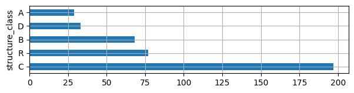

```python
df_building.groupby('structure_class').size().sort_values(ascending=False).plot(kind='barh', grid=True, figsize=(7, 1.5));
```

```python
# Distribution on land square footage: Land area of parcel (square feet)
pd.set_option('display.float_format', lambda x: '%.2f' % x)
df_building.land_sf.describe()
```

```
count       404.00
mean      86390.63
std      509180.76
min           0.00
25%        4006.00
50%        9548.50
75%       25354.50
max     7397130.00
Name: land_sf, dtype: float64
```

**⭐ Findings:**

- We can use `land_sf` as a filter or as a attribute for visualization to control the size of respective icon/drop-pin based on the size of the land.
- We can use `structure_class` as a filter or tell a story, for example *"What are these landmarks made of? (Brick/Concrete, Reinforced Concrete, Wood/Frame, etc.)"*

#### `Building age` Category

```python
# Category: Building age
df_building[df_building.columns.intersection(df_description[df_description.Category == "Building age"]["Field Name"].tolist())].head(20)
```

|  | year_built_class | yr_built |
| --- | --- | --- |
| 0 | 1950-1979 | 1970.00 |
| 1 | 1950-1979 | 1964.00 |
| 2 | Pre-1915 | 1910.00 |
| 3 | 1980-present | 2013.00 |
| 4 | 1980-present | 2018.00 |
| 5 | 1980-present | 2018.00 |
| 6 | 1980-present | 2012.00 |
| 7 | 1980-present | 2018.00 |
| 8 | 1915-1949 | 1928.00 |
| 9 | 1980-present | 1980.00 |
| 10 | 1950-1979 | 1971.00 |
| 11 | 1950-1979 | 1959.00 |
| 12 | 1915-1949 | 1950.00 |
| 13 | 1915-1949 | 1934.00 |
| 14 | 1980-present | 2017.00 |
| 15 | 1980-present | 2001.00 |
| 16 | Pre-1915 | 1899.00 |
| 17 | 1915-1949 | 1920.00 |
| 18 | 1915-1949 | 1920.00 |
| 19 | Pre-1915 | 1907.00 |

```python
df_building.groupby('year_built_class').size().sort_values(ascending=False)
```

```
year_built_class
Pre-1915        257
1915-1949        92
1980-present     29
1950-1979        26
dtype: int64
```

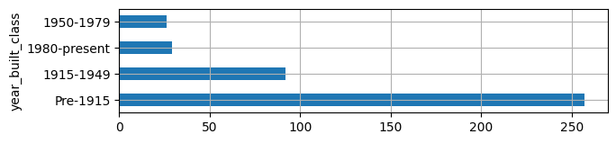

```python
df_building.groupby('year_built_class').size().sort_values(ascending=False).plot(kind='barh', grid=True, figsize=(7, 1.5));
```

**⭐ Findings:**

- Apparently, there are many more landmarks that were built in `Pre-1915`.
- We can use this default classification as our filter on the map.

#### `Building size` Category

Agreegated with `land_sf` column from *Other* category for comparison, which described as *Land area of parcel (square feet)*.

```python
# Category: Building size
df_building[df_building.columns.intersection(df_description[df_description.Category == "Building size"]["Field Name"].tolist() + ['land_sf'])].head(20)
```

|  | sqft_class | land_sf | gross_area | living_area | sqft |
| --- | --- | --- | --- | --- | --- |
| 0 | < 25,000 sqft | 3948992.00 | 7600.00 | 3800.00 | 7600.00 |
| 1 | >= 100,000 sqft | 174782.00 | 445701.00 | 398510.00 | 398510.00 |
| 2 | >= 100,000 sqft | 13631.00 | 138172.00 | 125124.00 | 125124.00 |
| 3 | >= 100,000 sqft | 21388.00 | 392200.00 | 384000.00 | 384000.00 |
| 4 | 50,000-99,999 sqft | 6720.00 | 85700.00 | 85700.00 | 85700.00 |
| 5 | >= 100,000 sqft | 48625.00 | 210000.00 | 141925.00 | 141925.00 |
| 6 | >= 100,000 sqft | 30287.00 | 488713.00 | 488713.00 | 488713.00 |
| 7 | 50,000-99,999 sqft | 12282.00 | 95000.00 | 95000.00 | 95000.00 |
| 8 | >= 100,000 sqft | 383072.00 | 1380017.00 | 1180548.00 | 1380017.00 |
| 9 | >= 100,000 sqft | 61477.00 | 1344121.00 | 1303391.00 | 1344121.00 |
| 10 | >= 100,000 sqft | 17468.00 | 176088.00 | 161173.00 | 176088.00 |
| 11 | >= 100,000 sqft | 20157.00 | 130000.00 | 120000.00 | 130000.00 |
| 12 | >= 100,000 sqft | 6339.00 | 350000.00 | 350000.00 | 350000.00 |
| 13 | >= 100,000 sqft | 82276.00 | 287107.00 | 245873.00 | 287107.00 |
| 14 | >= 100,000 sqft | 4311.00 | 131312.00 | 98484.00 | 131312.00 |
| 15 | >= 100,000 sqft | 6972.00 | 129200.00 | 129200.00 | 129200.00 |
| 16 | >= 100,000 sqft | 48382.00 | 744526.00 | 699694.00 | 744526.00 |
| 17 | >= 100,000 sqft | 15128.00 | 178130.00 | 163834.00 | 178130.00 |
| 18 | >= 100,000 sqft | 19534.00 | 256223.00 | 241963.00 | 256223.00 |
| 19 | >= 100,000 sqft | 25303.00 | 453564.00 | 403470.00 | 453564.00 |

```python
df_building.groupby('sqft_class').size().sort_values(ascending=False)
```

```
sqft_class
< 25,000 sqft         245
>= 100,000 sqft        69
50,000-99,999 sqft     47
25,000-34,999 sqft     29
35,000-49,999 sqft     13
dtype: int64
```

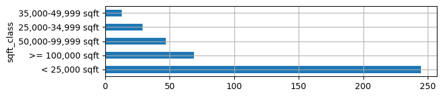

```python
df_building.groupby('sqft_class').size().sort_values(ascending=False).plot(kind='barh', grid=True, figsize=(7, 1.5));
```

**⭐ Findings:**

- Building size information here is different from what we have seen in `land_sf` column. We may need to decide which attribute to use.
- From the bar chart we can see the majority of landmarks are `< 25,000 sqft`, and a good number of landmarks are huge which are `>= 100,000 sqft`.

#### `Height` Category

```python
# Category: Height
df_building[df_building.columns.intersection(df_description[df_description.Category == "Height"]["Field Name"].tolist())].head(20)
```

|  | num_floors |
| --- | --- |
| 0 | 1.00 |
| 1 | 29.00 |
| 2 | 11.00 |
| 3 | 30.00 |
| 4 | 13.00 |
| 5 | 13.00 |
| 6 | 27.00 |
| 7 | 24.00 |
| 8 | 12.00 |
| 9 | 32.00 |
| 10 | 17.00 |
| 11 | 12.00 |
| 12 | 1.00 |
| 13 | 11.00 |
| 14 | 12.00 |
| 15 | 19.00 |
| 16 | 20.00 |
| 17 | 13.00 |
| 18 | 13.00 |
| 19 | 17.00 |

```python
df_building.groupby('num_floors').size().sort_values(ascending=False)
```

```
num_floors
4.00     63
3.00     59
2.00     57
5.00     51
1.00     46
2.50     27
6.00     22
8.00      8
7.00      8
10.00     7
9.00      7
11.00     6
12.00     6
3.50      5
13.00     5
4.50      5
6.50      2
1.50      2
14.00     2
17.00     2
29.00     1
40.00     1
32.00     1
31.00     1
30.00     1
24.00     1
28.00     1
27.00     1
26.00     1
20.00     1
19.00     1
42.00     1
dtype: int64
```

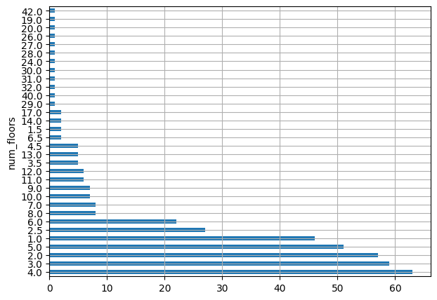

```python
df_building.groupby('num_floors').size().sort_values(ascending=False).plot(kind='barh', grid=True, figsize=(7, 5));
```

**⭐ Findings:**

- Height of buildings can be used to set size or shape of markers on the map.

#### `Number of buildings` Category

- We can remove this column since all data points have `num_bldgs = 1`.

```python
# Category: Number of buildings
df_building.groupby('num_bldgs').size().sort_values(ascending=False)
```

```
num_bldgs
1.00    404
dtype: int64
```

```python
df_building.drop('num_bldgs', axis=1, inplace=True)
```

#### `Number of units` Category

- We can remove this category since they have great data missingness.

```python
# Category: Number of units
df_building[df_building.columns.intersection(df_description[df_description.Category == "Number of units"]["Field Name"].tolist())].describe()
```

|  | units_res | units_com | units_mixed |
| --- | --- | --- | --- |
| count | 125.00 | 4.00 | 0.00 |
| mean | 19.58 | 5.00 | NaN |
| std | 38.65 | 1.15 | NaN |
| min | 1.00 | 4.00 | NaN |
| 25% | 2.00 | 4.00 | NaN |
| 50% | 3.00 | 5.00 | NaN |
| 75% | 24.00 | 6.00 | NaN |
| max | 273.00 | 6.00 | NaN |

```python
df_building.drop('units_res', axis=1, inplace=True)
df_building.drop('units_com', axis=1, inplace=True)
df_building.drop('units_mixed', axis=1, inplace=True)
```

#### `Zoning` Category

- We can remove column `landmark` since this was used for initial data filtering, all data points remaining are indeed landmarks.

```python
# Category: Zoning
df_building[df_building.columns.intersection(df_description[df_description.Category == "Zoning"]["Field Name"].tolist())].head()
```

|  | historic_district | landmark |
| --- | --- | --- |
| 0 | f | t |
| 1 | f | t |
| 2 | f | t |
| 3 | f | t |
| 4 | f | t |

```python
df_building.groupby('historic_district').size().sort_values(ascending=False)
```

```
historic_district
f    357
t     47
dtype: int64
```

```python
df_building.groupby('landmark').size().sort_values(ascending=False)
```

```
landmark
t    404
dtype: int64
```

**⭐ Findings:**

- Whether a building is in a historic district or not may be useful for filtering or visualization.

#### `Environmental` Category

- This category may not be useful for our visualization, will remove these columns.

```python
# Category: Environmental
df_building[df_building.columns.intersection(df_description[df_description.Category == "Environmental"]["Field Name"].tolist())].head()
```

|  | flood | stormwater |
| --- | --- | --- |
| 0 | t | t |
| 1 | f | f |
| 2 | t | t |
| 3 | t | t |
| 4 | f | f |

```python
# flood = Whether the property falls within the 1% annual flood zone, assuming 36 inches of sea level rise
df_building.groupby('flood').size().sort_values(ascending=False)
```

```
flood
f    317
t     87
dtype: int64
```

```python
# stormwater = Whether the property falls within the stormwater flood zone
df_building.groupby('stormwater').size().sort_values(ascending=False)
```

```
stormwater
f    323
t     81
dtype: int64
```

```python
df_building.drop('flood', axis=1, inplace=True)
df_building.drop('stormwater', axis=1, inplace=True)
```

#### `Heat Pump Strategy` Category

- This category may not be useful for our visualization, will remove these columns.

```python
# Category: Heat Pump Strategy
df_building[df_building.columns.intersection(df_description[df_description.Category == "Heat Pump Strategy"]["Field Name"].tolist())].head()
```

|  | cashp_only | cashp_and_elec_upgrade | cashp_outdoor | dashp_only | dashp_and_elec_upgrade | dashp_outdoor | gshp_only | gshp_and_elec_upgrade | vrf_only | vrf_and_elec_upgrade | awhp_only | awhp_and_elec_upgrade | hp_recommendation_count |
| --- | --- | --- | --- | --- | --- | --- | --- | --- | --- | --- | --- | --- | --- |
| 0 | f | f | f | f | f | f | f | f | f | f | f | f | 0 |
| 1 | f | f | f | f | f | f | f | f | f | f | f | f | 0 |
| 2 | f | f | f | f | f | f | f | f | f | f | f | f | 0 |
| 3 | f | f | f | f | f | f | f | f | f | f | f | f | 0 |
| 4 | f | f | f | f | f | f | f | f | f | f | f | f | 0 |

```python
columns_to_remove = [
    'cashp_only', 'cashp_and_elec_upgrade', 'cashp_outdoor',
    'dashp_only', 'dashp_and_elec_upgrade', 'dashp_outdoor',
    'gshp_only', 'gshp_and_elec_upgrade',
    'vrf_only', 'vrf_and_elec_upgrade',
    'awhp_only', 'awhp_and_elec_upgrade',
    'hp_recommendation_count'
]

df_building.drop(columns=columns_to_remove, inplace=True)
```

#### `Envelope Strategy` Category

- This category may not be useful for our visualization, will remove these columns.

```python
# Category: Envelope Strategy
df_building[df_building.columns.intersection(df_description[df_description.Category == "Envelope Strategy"]["Field Name"].tolist())].head()
```

|  | insulate_attic | insulate_attic_converted | ext_roof_insulation | insulate_exposed_ducts | insulate_exposed_pipes | interior_wall_insulation_blow_in | exterior_wall_insulation_at_replacement | exterior_wall_insulation | interior_wall_insulation_board | insulate_spandrel | asbestos | seal_elevator_vent_shafts | env_recommendation_count |
| --- | --- | --- | --- | --- | --- | --- | --- | --- | --- | --- | --- | --- | --- |
| 0 | f | f | f | f | f | f | f | f | f | f | f | f | 0 |
| 1 | f | f | t | f | f | f | f | f | f | f | f | t | 2 |
| 2 | f | f | t | f | f | f | f | f | f | f | f | t | 2 |
| 3 | f | f | f | f | f | f | f | f | f | f | f | t | 1 |
| 4 | f | f | f | f | f | f | f | f | f | f | f | t | 1 |

```python
columns_to_remove = [
    'insulate_attic', 'insulate_attic_converted', 'ext_roof_insulation',
    'insulate_exposed_ducts', 'insulate_exposed_pipes',
    'interior_wall_insulation_blow_in', 'exterior_wall_insulation_at_replacement',
    'exterior_wall_insulation', 'interior_wall_insulation_board',
    'insulate_spandrel', 'asbestos', 'seal_elevator_vent_shafts',
    'env_recommendation_count'
]

df_building.drop(columns=columns_to_remove, inplace=True)
```

Checking our building dataset after this round of treatments.

```python
df_building.drop('zipcode5', axis=1, inplace=True)
```

```python
df_building.head()
```

|  | id | pid_long | cm_id | building_typology | building_subtypology | use_class | sqft_class | year_built_class | st_num | st_name | ... | assessor_category | assessor_description | owner_list | structure_class | historic_district | landmark | full_address | lat | lon | coordinate |
| --- | --- | --- | --- | --- | --- | --- | --- | --- | --- | --- | --- | --- | --- | --- | --- | --- | --- | --- | --- | --- | --- |
| 0 | 94001 | 2200577000.00 | NaN | Convention/Assembly | Convention/Assembly, 1950-1979 | Public & Quasi-Public | < 25,000 sqft | 1950-1979 | 525 | WESTERN | ... | Exempt Property Type | Auditorium / Theater | COMMONWEALTH OF MASSCHUSETTS | C | f | t | 525 WESTERN AVE, Boston, MA 02135 | 42.36 | -71.14 | 42.361588714285716, -71.14472929591837 |
| 1 | 4303 | 1002149000.00 | NaN | Multi-Family (>= 100 units) | Multi-Family (>= 100 units), 1950-1979 | Residential | >= 100,000 sqft | 1950-1979 | 111 | PERKINS | ... | Multiple Use Property | Res/Commercial Use | JAMAICAWAY TOWER & TOWNHOUSE | B | f | t | 111 PERKINS ST, Boston, MA 02130 | 42.32 | -71.12 | 42.3222244, -71.1154261 |
| 2 | 71547 | 303823000.00 | NaN | Multi-Family (31-99 units) | Multi-Family (31-99 units), Pre-1915 | Residential | >= 100,000 sqft | Pre-1915 | 131 | STATE | ... | Multiple Use Property | Res/Commercial Use | TISHMAN SPEYER ARCHSTONE- | A | f | t | 131 STATE ST, Boston, MA 02109 | 42.36 | -71.05 | 42.35898245, -71.05422705000001 |
| 3 | 38651 | 304910020.00 | NaN | NaN | NaN | Residential | >= 100,000 sqft | 1980-present | 24 -58 | LAGRANGE | ... | Apartment Property | Apartment | AVALON STUART LLC | A | f | t | 24 -58 LAGRANGE ST, Boston, MA 02116 | 42.35 | -71.06 | 42.3516363, -71.0640237 |
| 4 | 97181 | 303883000.00 | NaN | Hotel | Hotel, 1980-present | Commercial | 50,000-99,999 sqft | 1980-present | 56 - 68 | DEVONSHIRE | ... | Commercial Property | Hotel/Lodging | MHF DEVONSHIRE V LLC | A | f | t | 56 - 68 DEVONSHIRE ST, Boston, MA 02109 | 42.36 | -71.06 | 42.3582819, -71.0572806 |

5 rows × 31 columns

#### Boston Landmark Commission Dataset

```python
df_blc = pd.read_csv("blc_data_with_coordinate.csv")
```

```python
df_blc.head()
```

|  | PETITION | NAME OF PROPERTY | ADDRESS | NEIGHBORHOOD | PETITION BY | CATEGORY | DETAILS | full_address | lat | lon | coordinate |
| --- | --- | --- | --- | --- | --- | --- | --- | --- | --- | --- | --- |
| 0 | 289 | Charlestown Industrial Architectural Conservat... | See Map | Charlestown | 10 voters | C = Pending Landmark/District | Under study - July 2023 | See Map, Charlestown, MA, USA | NaN | NaN | NaN |
| 1 | 288 | Hotel Buckminster | 635-645 Beacon Street | Kenmore | 10 voters | A = Individual Landmark | BLC designation vote 2023 | 635-645 Beacon Street, Kenmore, MA, USA | 42.35 | -71.10 | 42.3471315, -71.1033303 |
| 2 | 287 | Monument Square Landmark District | See Map | Charlestown | 10 Voters | C = Pending Landmark/District | Under study - Jul 2022 | See Map, Charlestown, MA, USA | NaN | NaN | NaN |
| 3 | 286 | William S. Keith House | 1911 Centre St | West Roxbury | 10 voters | D = Designated or Pending but Demolished | Razed 2022 | 1911 Centre St, West Roxbury, MA, USA | 42.28 | -71.16 | 42.28498645, -71.15685764135037 |
| 4 | 285 | Blue Hill Bank | 1110 Washington St | Mattapan | 10 voters | C = Pending Landmark/District | Under study - Mar 2022 | 1110 Washington St, Mattapan, MA, USA | 42.27 | -71.07 | 42.2721879, -71.0681849 |

```python
df_blc.tail(15)
```

|  | PETITION | NAME OF PROPERTY | ADDRESS | NEIGHBORHOOD | PETITION BY | CATEGORY | DETAILS | full_address | lat | lon | coordinate |
| --- | --- | --- | --- | --- | --- | --- | --- | --- | --- | --- | --- |
| 289 | 2 | Armory of 1st Corps Cadets (exterior see #40) | Arlington @ Columbus | South Cove | Commissioner | A = Individual Landmark | BLC Designation vote 1977 | Arlington @ Columbus, South Cove, MA, USA | NaN | NaN | NaN |
| 290 | 1 | St. Mary of the Sacred Heart Church | 24 Thatcher St | North End | 10 Voters | E = Unsuccessful Petition | Denied 1/25/1977 | 24 Thatcher St, North End, MA, USA | 43.62 | -116.20 | 43.6239616, -116.1962685 |
| 291 | ** | Back Bay District 1966 | See Map | NaN | NaN | B = District | **predates BLC | NaN | 46.31 | 11.05 | 46.3144754, 11.0480288 |
| 292 | * | Historic Beacon Hill District: Acts 1955, Ch 616 | See Map | NaN | NaN | B = District | *predates BLC | NaN | 46.31 | 11.05 | 46.3144754, 11.0480288 |
| 293 | NaN | NaN | NaN | NaN | NaN | NaN | NaN | NaN | 46.31 | 11.05 | 46.3144754, 11.0480288 |
| 294 | NaN | NaN | NaN | NaN | NaN | 96 | NaN | NaN | 46.31 | 11.05 | 46.3144754, 11.0480288 |
| 295 | NaN | NaN | NaN | NaN | NaN | NaN | NaN | NaN | 46.31 | 11.05 | 46.3144754, 11.0480288 |
| 296 | NaN | Landmark Categories | NaN | NaN | NaN | NaN | NaN | NaN | 46.31 | 11.05 | 46.3144754, 11.0480288 |
| 297 | NaN | A = Individual Landmark | NaN | NaN | NaN | NaN | NaN | NaN | 46.31 | 11.05 | 46.3144754, 11.0480288 |
| 298 | NaN | B = District | NaN | NaN | NaN | NaN | NaN | NaN | 46.31 | 11.05 | 46.3144754, 11.0480288 |
| 299 | NaN | C = Pending Landmark/District | NaN | NaN | NaN | NaN | NaN | NaN | 46.31 | 11.05 | 46.3144754, 11.0480288 |
| 300 | NaN | D = Designated or Pending but Demolished | NaN | NaN | NaN | NaN | NaN | NaN | 46.31 | 11.05 | 46.3144754, 11.0480288 |
| 301 | NaN | E = Unsuccessful Petition | NaN | NaN | NaN | NaN | NaN | NaN | 46.31 | 11.05 | 46.3144754, 11.0480288 |
| 302 | NaN | F = Unsuccessful Petition & Demolished | NaN | NaN | NaN | NaN | NaN | NaN | 46.31 | 11.05 | 46.3144754, 11.0480288 |
| 303 | NaN | O = Other, non-designation action | NaN | NaN | NaN | NaN | NaN | NaN | 46.31 | 11.05 | 46.3144754, 11.0480288 |

```python
# Removing index 291 to 303 as they are not useful data
df_blc = df_blc.drop(index=range(291, 304))
```

```python
df_blc.tail()
```

|  | PETITION | NAME OF PROPERTY | ADDRESS | NEIGHBORHOOD | PETITION BY | CATEGORY | DETAILS | full_address | lat | lon | coordinate |
| --- | --- | --- | --- | --- | --- | --- | --- | --- | --- | --- | --- |
| 286 | 5 | Public Garden | Beacon St | Boston, Downtown | Commissioner | A = Individual Landmark | BLC Designation vote 1977 | Beacon St, Boston, Downtown, MA, USA | 42.36 | -71.06 | 42.3582214, -71.0612733 |
| 287 | 4 | Boston Common | Beacon Street | Downtown | Commissioner | A = Individual Landmark | BLC Designation vote 1977 | Beacon Street, Downtown, MA, USA | 42.36 | -71.06 | 42.3582214, -71.0612733 |
| 288 | 3 | Donald McKay House [barn razed 5-2022, owner m... | 80 White St | East Boston | Commissioner | A = Individual Landmark | BLC Designation vote 1977 | 80 White St, East Boston, MA, USA | 42.38 | -71.03 | 42.380454875000005, -71.03463125 |
| 289 | 2 | Armory of 1st Corps Cadets (exterior see #40) | Arlington @ Columbus | South Cove | Commissioner | A = Individual Landmark | BLC Designation vote 1977 | Arlington @ Columbus, South Cove, MA, USA | NaN | NaN | NaN |
| 290 | 1 | St. Mary of the Sacred Heart Church | 24 Thatcher St | North End | 10 Voters | E = Unsuccessful Petition | Denied 1/25/1977 | 24 Thatcher St, North End, MA, USA | 43.62 | -116.20 | 43.6239616, -116.1962685 |

```python
df_blc.groupby('NEIGHBORHOOD').size().sort_values(ascending=False)
```

```
NEIGHBORHOOD
Boston, Downtown        59
Dorchester              32
Back Bay                22
Roxbury                 19
Boston, CBD             18
Theater                 16
Fenway                  16
Brighton                15
Charlestown             10
East Boston             10
Jamaica Plain           10
South End               10
North End                7
Boston                   6
Mission Hill             5
South Boston             5
Mattapan                 4
Beacon Hill              4
West Roxbury             3
South Cove               2
Allston                  2
Longwood                 2
Kenmore                  2
Downtown                 2
Hyde Park                1
E & S Boston             1
Seaport                  1
Charles River            1
Beacon Hill/Back Bay     1
Bay Village              1
Waterfront               1
Fenway, JP               1
dtype: int64
```

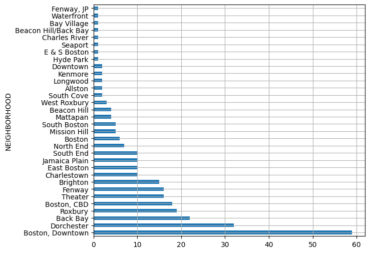

```python
df_blc.groupby('NEIGHBORHOOD').size().sort_values(ascending=False).plot(kind='barh', grid=True, figsize=(7, 6));
```

```python
df_blc.groupby('PETITION BY').size().sort_values(ascending=False)
```

```
PETITION BY
10 Voters       188
Commissioner     56
10 voters        41
10 Voters         1
City Council      1
Mayor             1
dtype: int64
```

```python
df_blc.groupby('CATEGORY').size().sort_values(ascending=False)
```

```
CATEGORY
A = Individual Landmark                                                     108
C = Pending Landmark/District                                                84
E = Unsuccessful Petition                                                    64
B = District                                                                  9
F = Unsuccessful Petition & Demolished                                        9
O = Other, non-designation action                                             8
D = Designated or Pending but Demolished                                      6
A= Individual Landmark                                                        2
C = Pending Landmark/District \nD = Designated or Pending but Demolished      1
dtype: int64
```

```python
# Locating 1 seemingly error data points and fix or remove them
df_blc[df_blc['CATEGORY'].isin(['C = Pending Landmark/District \nD = Designated or Pending but Demolished'])]
```

|  | PETITION | NAME OF PROPERTY | ADDRESS | NEIGHBORHOOD | PETITION BY | CATEGORY | DETAILS | full_address | lat | lon | coordinate |
| --- | --- | --- | --- | --- | --- | --- | --- | --- | --- | --- | --- |
| 12 | 277 | Union Street Architectural Conservation District | 30 Union Street (pending) and 8 Lawrence (raze... | Charlestown | 10 voters | C = Pending Landmark/District \nD = Designated... | Under study - Aug 10, 2021 | 30 Union Street (pending) and 8 Lawrence (raze... | NaN | NaN | NaN |

```python
df_blc.at[12, 'CATEGORY'] = 'D = Designated or Pending but Demolished'
```

```python
# Fixing two data points with `A= Individual Landmark` typo
df_blc[df_blc['CATEGORY'].isin(['A= Individual Landmark'])]
```

|  | PETITION | NAME OF PROPERTY | ADDRESS | NEIGHBORHOOD | PETITION BY | CATEGORY | DETAILS | full_address | lat | lon | coordinate |
| --- | --- | --- | --- | --- | --- | --- | --- | --- | --- | --- | --- |
| 25 | 264 | North Bennet Street Bath House & Gymnasium (Na... | 30-32 N. Bennet St | North End | 10 Voters | A= Individual Landmark | BLC designation vote 2023 | 30-32 N. Bennet St, North End, MA, USA | 42.37 | -71.05 | 42.3653054, -71.0542542 |
| 157 | 132 | Richardson Block | 109-151 Pearl St | Boston, Downtown | 10 Voters | A= Individual Landmark | BLC Designation vote 2023 | 109-151 Pearl St, Boston, Downtown, MA, USA | NaN | NaN | NaN |

```python
df_blc.at[25, 'CATEGORY'] = 'A = Individual Landmark'
df_blc.at[157, 'CATEGORY'] = 'A = Individual Landmark'
```

```python
# Checking again
df_blc.groupby('CATEGORY').size().sort_values(ascending=False)
```

```
CATEGORY
A = Individual Landmark                     110
C = Pending Landmark/District                84
E = Unsuccessful Petition                    64
B = District                                  9
F = Unsuccessful Petition & Demolished        9
O = Other, non-designation action             8
D = Designated or Pending but Demolished      7
dtype: int64
```

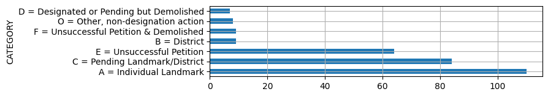

```python
df_blc.groupby('CATEGORY').size().sort_values(ascending=False).plot(kind='barh', grid=True, figsize=(7, 1.5));
```

**⭐ Findings:**

- It might be interesting to see how many petitions are in different neighborhoods, but we only have this data in the Boston Landmarks Commission dataset.
- We can use `CATEGORY` to show petitions in different status, but we need to think what do we do with `A = Individual Landmark` which seemingly approved landmarks.

### Export Datasets for Initial Map Visualization

There are still many data points with missing geo coordinates, we will remove those entries for now and manually fill in later on.

```python
df_building['coordinate'].isna().sum()
```

[output not shown]

```python
df_building = df_building.dropna(subset=['coordinate'])
print("Number of landmarks in Buildings dataset after removing missing coordinates:", df_building.shape[0])
```

```
Number of landmarks in Buildings dataset after removing missing coordinates: 371
```

```python
df_blc['coordinate'].isna().sum()
```

```
72
```

```python
df_blc = df_blc.dropna(subset=['coordinate'])
print("Number of landmarks in Buildings dataset after removing missing coordinates:", df_blc.shape[0])
```

```
Number of landmarks in Buildings dataset after removing missing coordinates: 219
```

```python
# Save the datasets for future use
df_building.to_csv('building_data_cleaned.csv', index=False)
df_blc.to_csv('blc_data_cleaned.csv', index=False)
```

### Visualization Schematic

Interactive Map with 4 Layers:

- Actual Landmarks: Historical Register Layer
- Would-Be Landmarks: Pending Status Layer
- Could've-Been Landmarks: Rejected Petition Layer
- Your Landmarks: Interactive Community Layer. Allows museum visitors to add their personal landmarks to the map, democratizing the concept of landmarks and acknowledging the significance of everyday locations.

Plus, a flow chart shows how to a landmark becomes a landmark.